# Deep Dive Sentinel 2 labels for training set

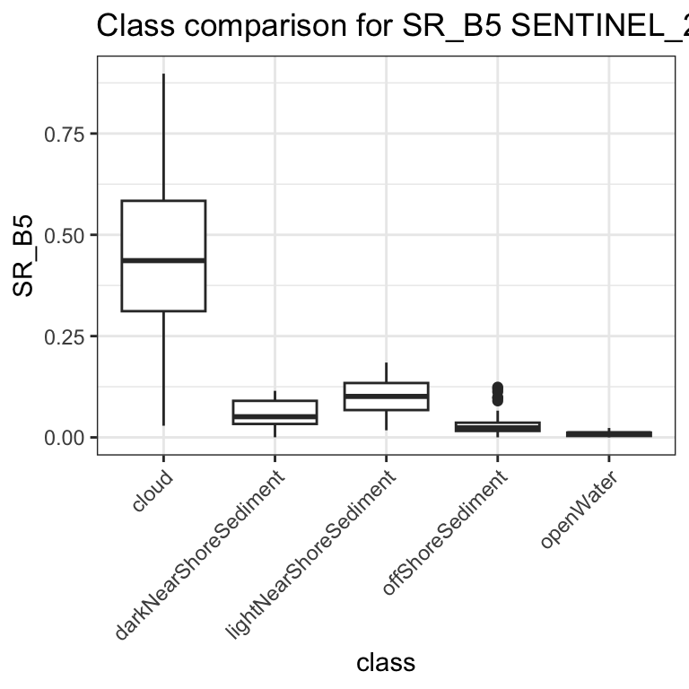

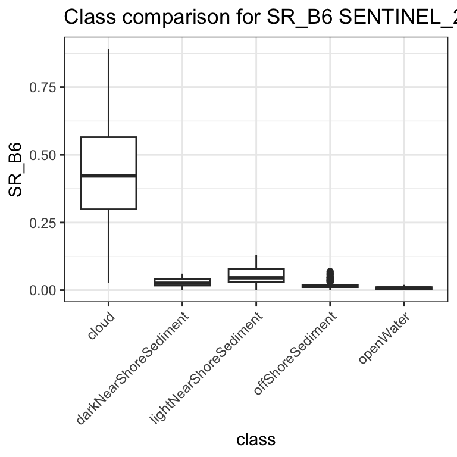

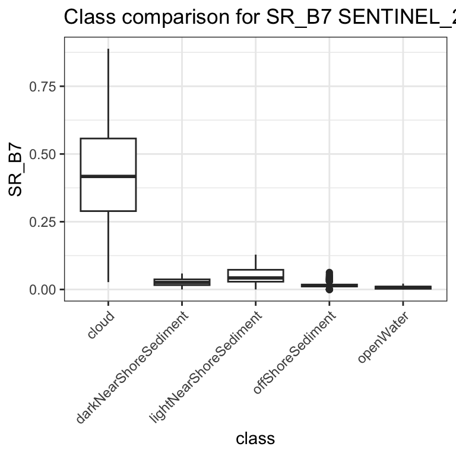

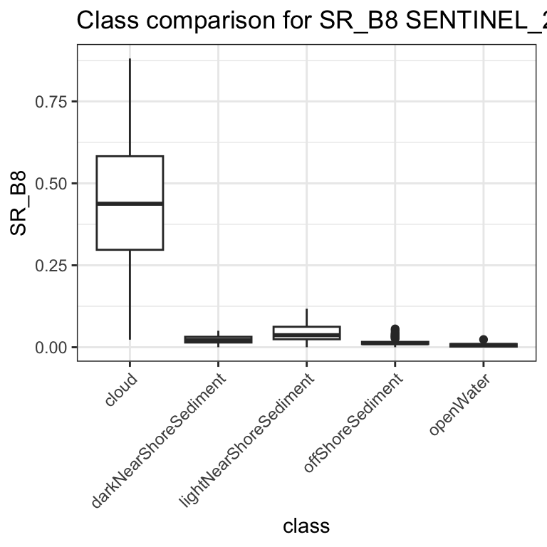

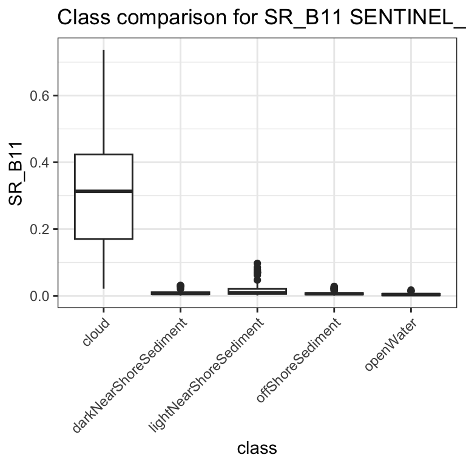

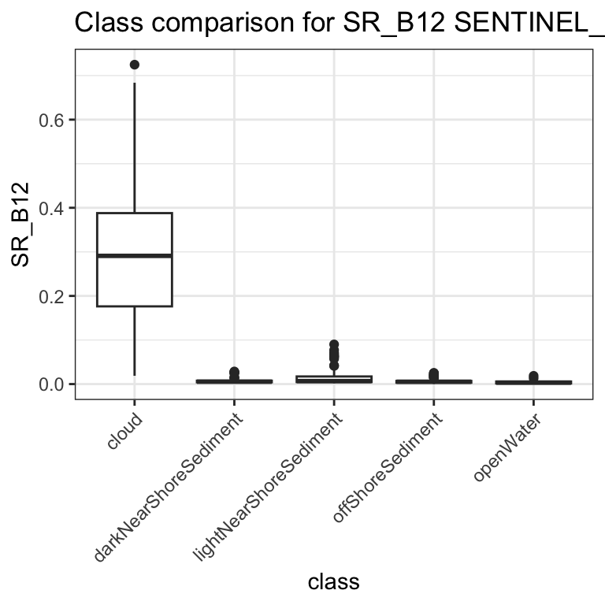

Like with LS8/9 - the classes look really similar in distribution (maybe because cloud categories are so high). It will be interesting to see if there are statistical differences.

## Outlier handling

There are statistical outliers within this dataset and they may impact the interpretation of any statistical testing we do. Let’s see if we can narrow down when those outliers and/or glean anything from the outlier data that may be applicable to the the application of the algorithm. Outliers may be a systemic issue (as in the scene is an outlier), it could be a user issue (a user may have been a bad actor), or they just might be real. This section asks those questions. The “true outliers” that we dismiss from the dataset will also be used to help aid in interpretation/application of the algorithm across the Landsat stack, so it is important to make notes of any patterns we might see in the outlier dataset.

```
## [1] "Classes represented in outliers:"
```

```
## [1] "darkNearShoreSediment"  "lightNearShoreSediment" "offShoreSediment"
## [4] "openWater"
```

How many of these outliers are in specific scenes?

```r
S2_out_date <- outliers %>%
  group_by(date, vol_init) %>%
  summarize(n_out = n())
S2_date <- S2_for_class_analysis %>%
  filter(class != "cloud") %>%
  group_by(date, vol_init) %>%
  summarise(n_tot = n())
S2_out_date <- left_join(S2_out_date, S2_date) %>%
  mutate(percent_outlier = n_out/n_tot*100) %>%
  arrange(-percent_outlier)
S2_out_date %>%
  kable()
```

| date | vol_init | n_out | n_tot | percent_outlier |
| --- | --- | --- | --- | --- |
| 2022-06-23 | BJM | 8 | 32 | 25.000000 |
| 2023-04-11 | BJM | 6 | 32 | 18.750000 |
| 2019-06-06 | LRCP | 9 | 161 | 5.590062 |
| 2020-10-26 | BJM | 1 | 19 | 5.263158 |
| 2020-09-28 | BJM | 1 | 33 | 3.030303 |
| 2021-08-29 | ANK | 1 | 63 | 1.587302 |
| 2019-05-12 | LRCP | 1 | 93 | 1.075269 |

Let’s look at the tile-level metadata for the highest scenes here:

```r
S2_out_date %>%
  filter(percent_outlier > 20) %>%
  select(date, vol_init) %>%
  left_join(., S2) %>%
  select(date, vol_init, GENERAL_QUALITY:WATER_VAPOUR_RETRIEVAL_ACCURACY_min) %>%
  distinct() %>%
  kable()
```

| date | vol_init | GENERAL_QUALITY | GEOMETRIC_QUALITY | RADIOMETRIC_QUALITY | AOT_RETRIEVAL_ACCURACY_mean | CLOUDY_PIXEL_PERCENTAGE_mean | CLOUD_COVERAGE_ASSESSMENT_mean | CLOUD_SHADOW_PERCENTAGE_mean | DARK_FEATURES_PERCENTAGE_mean | HIGH_PROBA_CLOUDS_PERCENTAGE_mean | MEDIUM_PROBA_CLOUDS_PERCENTAGE_mean | NODATA_PIXEL_PERCENTAGE_mean | SATURATED_DEFECTIVE_PIXEL_PERCENTAGE_mean | SNOW_ICE_PERCENTAGE_mean | THIN_CIRRUS_PERCENTAGE_mean | WATER_VAPOUR_RETRIEVAL_ACCURACY_mean | AOT_RETRIEVAL_ACCURACY_max | CLOUDY_PIXEL_PERCENTAGE_max | CLOUD_COVERAGE_ASSESSMENT_max | CLOUD_SHADOW_PERCENTAGE_max | DARK_FEATURES_PERCENTAGE_max | HIGH_PROBA_CLOUDS_PERCENTAGE_max | MEDIUM_PROBA_CLOUDS_PERCENTAGE_max | NODATA_PIXEL_PERCENTAGE_max | SATURATED_DEFECTIVE_PIXEL_PERCENTAGE_max | SNOW_ICE_PERCENTAGE_max | THIN_CIRRUS_PERCENTAGE_max | WATER_VAPOUR_RETRIEVAL_ACCURACY_max | AOT_RETRIEVAL_ACCURACY_min | … |
| --- | --- | --- | --- | --- | --- | --- | --- | --- | --- | --- | --- | --- | --- | --- | --- | --- | --- | --- | --- | --- | --- | --- | --- | --- | --- | --- | --- | --- | --- | --- |
| 2022-06-23 | BJM | PASSED | PASSED | PASSED | 0 | 18.49813 | 18.49813 | 5.169074 | 0.0238785 | 8.764897 | 8.003182 | 43.23486 | 0 | 0 | 1.730047 | 0 | 0 | 26.09543 | 26.09543 | 6.242434 | 0.066476 | 11.80045 | 10.02683 | 94.67778 | 0 | 0 | 4.268137 | 0 | 0 | … |